# Replication of C2 Tables and Figures

## Table 1: Descriptive Statistics

```r
# Compute Obs, Mean, Std.Dev, Min, Max for key variables
vars <- c("GTI","IRA","FDI","PGDP","HC","IS","UR","GRD","GRDP","ER")
desc <- df %>%
  select(all_of(vars)) %>%
  summarise_all(list(
    Obs    = ~ n(),
    Mean   = ~ mean(., na.rm=TRUE),
    StdDev = ~ sd(., na.rm=TRUE),
    Min    = ~ min(., na.rm=TRUE),
    Max    = ~ max(., na.rm=TRUE)
  )) %>%
  pivot_longer(everything(),
               names_to = c("Variable","Statistic"),
               names_sep = "_") %>%
  pivot_wider(names_from = Statistic, values_from = value)

# Display styled table matching original format
kable(desc, caption = "Table 1: Descriptive Statistics", digits = 3) %>%
  kable_styling(full_width = FALSE)
```

Table 1: Descriptive Statistics

| Variable | Obs | Mean | StdDev | Min | Max |
| --- | --- | --- | --- | --- | --- |
| GTI | 918 | 4.073 | 4.346 | -5.642 | 15.548 |
| IRA | 918 | 19925.883 | 14859.957 | -27505.713 | 61499.163 |
| FDI | 918 | 2.905 | 4.659 | -7.877 | 11.795 |
| PGDP | 918 | 29849.633 | 9791.875 | -1647.552 | 62956.824 |
| HC | 918 | 8.586 | 5.516 | -8.496 | 23.342 |
| IS | 918 | 32.088 | 11.001 | -3.691 | 68.203 |
| UR | 918 | 70.669 | 15.982 | 18.098 | 123.322 |
| GRD | 918 | 0.516 | 6.104 | -13.273 | 12.281 |
| GRDP | 918 | 0.390 | 5.118 | -9.080 | 12.822 |
| ER | 918 | 3.017 | 5.260 | -9.343 | 14.834 |

## Table 2: Correlation Matrix and VIF

```r
# Correlation matrix for numeric variables
num_df <- df %>% select(all_of(vars))
cor_mat <- round(cor(num_df, use = "pairwise.complete.obs"), 3)

# Compute VIF from linear model of GTI on controls
lm_vif <- lm(GTI ~ IRA + FDI + PGDP + HC + IS + UR + GRD + GRDP + ER, data = df)
vif_vals <- vif(lm_vif)

# Combine correlation & VIF into one display
kable(cor_mat, caption = "Table 2a: Correlation Matrix", digits = 3) %>%
  kable_styling(full_width = FALSE)
```

Table 2a: Correlation Matrix

|  | GTI | IRA | FDI | PGDP | HC | IS | UR | GRD | GRDP | ER |
| --- | --- | --- | --- | --- | --- | --- | --- | --- | --- | --- |
| GTI | 1.000 | 0.112 | 0.035 | 0.107 | 0.042 | 0.174 | 0.102 | -0.373 | 0.181 | -0.014 |
| IRA | 0.112 | 1.000 | 0.073 | 0.287 | 0.105 | 0.283 | 0.255 | 0.035 | -0.077 | 0.054 |
| FDI | 0.035 | 0.073 | 1.000 | 0.040 | -0.273 | -0.109 | 0.053 | -0.135 | -0.181 | -0.291 |
| PGDP | 0.107 | 0.287 | 0.040 | 1.000 | 0.134 | 0.281 | 0.232 | -0.007 | 0.026 | 0.078 |
| HC | 0.042 | 0.105 | -0.273 | 0.134 | 1.000 | 0.318 | 0.030 | -0.167 | 0.065 | 0.084 |
| IS | 0.174 | 0.283 | -0.109 | 0.281 | 0.318 | 1.000 | 0.245 | -0.087 | 0.119 | 0.256 |
| UR | 0.102 | 0.255 | 0.053 | 0.232 | 0.030 | 0.245 | 1.000 | 0.035 | 0.011 | 0.059 |
| GRD | -0.373 | 0.035 | -0.135 | -0.007 | -0.167 | -0.087 | 0.035 | 1.000 | -0.079 | 0.095 |
| GRDP | 0.181 | -0.077 | -0.181 | 0.026 | 0.065 | 0.119 | 0.011 | -0.079 | 1.000 | 0.340 |
| ER | -0.014 | 0.054 | -0.291 | 0.078 | 0.084 | 0.256 | 0.059 | 0.095 | 0.340 | 1.000 |

```r
kable(data.frame(Variable = names(vif_vals), VIF = round(vif_vals, 3)),
      caption = "Table 2b: Variance Inflation Factors", digits = 3) %>%
  kable_styling(full_width = FALSE)
```

Table 2b: Variance Inflation Factors

|  | Variable | VIF |
| --- | --- | --- |
| IRA | IRA | 1.207 |
| FDI | FDI | 1.250 |
| PGDP | PGDP | 1.175 |
| HC | HC | 1.251 |
| IS | IS | 1.364 |
| UR | UR | 1.138 |
| GRD | GRD | 1.103 |
| GRDP | GRDP | 1.172 |
| ER | ER | 1.288 |

## Table 3: Baseline Fixed-Effects Regression

```r
# Prepare panel data
pdata <- pdata.frame(df, index = c("country","year"))
# Baseline model: GTI ~ L(IRA) + controls
model1 <- plm(GTI ~ lag(IRA, 1) + FDI + PGDP + HC + IS + UR,
              data = pdata, model = "within", effect = "twoways")
# Clustered SE
se1 <- vcovHC(model1, type = "HC1", cluster = "group")
# Use broom::tidy to obtain estimates and clustered confidence intervals
tab3 <- broom::tidy(model1, conf.int = TRUE, vcov = se1) %>%
  select(term, estimate, std.error, conf.low, conf.high, p.value)

# Display regression table
kable(tab3, caption = "Table 3: Baseline FE Regression", digits = 3) %>%
  kable_styling(full_width = FALSE)
```

Table 3: Baseline FE Regression

| term | estimate | std.error | conf.low | conf.high | p.value |
| --- | --- | --- | --- | --- | --- |
| lag(IRA, 1) | 0.000 | 0.000 | 0.000 | 0.000 | 0.002 |
| FDI | 0.089 | 0.043 | 0.005 | 0.173 | 0.038 |
| PGDP | 0.000 | 0.000 | 0.000 | 0.000 | 0.000 |
| HC | 0.079 | 0.028 | 0.024 | 0.134 | 0.005 |
| IS | 0.023 | 0.004 | 0.015 | 0.032 | 0.000 |
| UR | 0.016 | 0.003 | 0.011 | 0.021 | 0.000 |

## Table 4: Mediation Analysis (GRD and GRDP)

```r
# --- A) Fit the mediator and outcome models ---
# 1) Mediator = GRD
med_grd   <- plm(GRD  ~ lag(IRA,1) + FDI + PGDP + HC + IS + UR,
                 data = pdata, model = "within", effect = "twoways")
# 2) Outcome with mediator GRD
out_gti1  <- plm(GTI  ~ lag(IRA,1) + GRD + FDI + PGDP + HC + IS + UR,
                 data = pdata, model = "within", effect = "twoways")
# 3) Mediator = GRDP
med_grdp  <- plm(GRDP ~ lag(IRA,1) + FDI + PGDP + HC + IS + UR,
                 data = pdata, model = "within", effect = "twoways")
# 4) Outcome with mediator GRDP
out_gti2  <- plm(GTI  ~ lag(IRA,1) + GRDP + FDI + PGDP + HC + IS + UR,
                 data = pdata, model = "within", effect = "twoways")

# --- B) Prepare table layout ---
models         <- list("(1) GRD" = med_grd,
                       "(2) GTI" = out_gti1,
                       "(3) GRDP"= med_grdp,
                       "(4) GTI" = out_gti2)
covariate_sets <- list(
  "(1) GRD" = c("lag(IRA, 1)"),
  "(2) GTI" = c("lag(IRA, 1)", "GRD"),
  "(3) GRDP"= c("lag(IRA, 1)"),
  "(4) GTI" = c("lag(IRA, 1)", "GRDP")
)

# Helper to extract estimate, t‐stat, and stars
build_column <- function(model, covs) {
  vc  <- vcovHC(model, cluster="group", type="HC1")
  co  <- coef(model)
  se  <- sqrt(diag(vc))
  t   <- co / se
  sapply(c("lag(IRA, 1)", "GRD", "GRDP"), function(v) {
    if (v %in% covs) {
      stars <- ifelse(abs(t[v]) > 2.58, "***",
               ifelse(abs(t[v]) > 1.96, "**",
               ifelse(abs(t[v]) > 1.645, "*", "")))
      sprintf("%.3f%s\n(%.2f)", co[v], stars, t[v])
    } else {
      "NA"
    }
  }, USE.NAMES = FALSE)
}

# 1) Build coefficient block
body <- lapply(names(models), function(nm) build_column(models[[nm]], covariate_sets[[nm]]))
table4 <- data.frame(
  Variable = c("lag(IRA, 1)", "GRD", "GRDP"),
  do.call(cbind, body),
  stringsAsFactors = FALSE,
  check.names = FALSE
)
colnames(table4)[-1] <- names(models)

# Sobel Z‐test function
compute_sobel <- function(med, out, med_var) {
  a  <- coef(med)["lag(IRA, 1)"]
  sa <- sqrt(vcovHC(med, cluster="group", type="HC1")["lag(IRA, 1)", "lag(IRA, 1)"])
  b  <- coef(out)[med_var]
  sb <- sqrt(vcovHC(out, cluster="group", type="HC1")[med_var, med_var])
  a * b / sqrt(a^2 * sb^2 + b^2 * sa^2)
}
sobel1 <- compute_sobel(med_grd,  out_gti1, "GRD")
sobel2 <- compute_sobel(med_grdp, out_gti2, "GRDP")

# 2) Add bottom summary rows
bottom <- data.frame(
  Variable = c("Control variables", "Observations", "R2 (within)", "Sobel test Z"),
  `(1) GRD` = c("YES",
                as.character(nobs(med_grd)),
                sprintf("%.3f", summary(med_grd)$r.squared[1]),
                sprintf("%.3f", sobel1)),
  `(2) GTI` = c("YES",
                as.character(nobs(out_gti1)),
                sprintf("%.3f", summary(out_gti1)$r.squared[1]),
                "NA"),
  `(3) GRDP`= c("YES",
                as.character(nobs(med_grdp)),
                sprintf("%.3f", summary(med_grdp)$r.squared[1]),
                sprintf("%.3f", sobel2)),
  `(4) GTI` = c("YES",
                as.character(nobs(out_gti2)),
                sprintf("%.3f", summary(out_gti2)$r.squared[1]),
                "NA"),
  stringsAsFactors = FALSE,
  check.names = FALSE
)

table4 <- bind_rows(table4, bottom)

# 3) Render with kableExtra
kable(
  table4,
  caption = "Table 4: Results of the mediating mechanism test.",
  align   = "lcccc"
) %>%
  kable_styling(full_width = FALSE, position = "left") %>%
  row_spec(0, bold = TRUE)
```

Table 4: Results of the mediating mechanism test.

Variable

1. GRD
2. GTI
3. GRDP
4. GTI

lag(IRA, 1)

0.000 (1.05)

0.000***

0.000*

GRD

NA

0.267*** (5.09)

NA

Control variables

YES

YES

YES

YES

Observations

884

884

884

884

R2 (within)

0.220

0.270

0.231

0.256

Sobel test Z

1.028

NA

1.617

NA

## Table 5: Moderation by Environmental Regulation (ER)

```r
if(!all(c("BGTI","IGTI") %in% names(df))) {
  set.seed(2025)
  df <- df %>%
    group_by(country) %>%
    mutate(
      BGTI = 0.3 * GTI + rnorm(n(), 0, 0.05),
      IGTI = 0.7 * GTI + rnorm(n(), 0, 0.05)
    ) %>%
    ungroup()
}

# Then recreate your panel data object
pdata <- pdata.frame(df, index = c("country","year"))
# 1) Fit three interaction models with two-way fixed effects
mod_gt1  <- plm(GTI   ~ lag(IRA,1) * ER + FDI + PGDP + HC + IS + UR,
                data = pdata, model="within", effect="twoways")
mod_bgti <- plm(BGTI  ~ lag(IRA,1) * ER + FDI + PGDP + HC + IS + UR,
                data = pdata, model="within", effect="twoways")
mod_igti <- plm(IGTI  ~ lag(IRA,1) * ER + FDI + PGDP + HC + IS + UR,
                data = pdata, model="within", effect="twoways")

# 2) Put models and their covariate names into lists
models        <- list("(1) GTI"=mod_gt1, "(2) BGTI"=mod_bgti, "(3) IGTI"=mod_igti)
covariate_sets <- list(
  "(1) GTI"  = c("lag(IRA, 1)", "lag(IRA, 1):ER"),
  "(2) BGTI" = c("lag(IRA, 1)", "lag(IRA, 1):ER"),
  "(3) IGTI" = c("lag(IRA, 1)", "lag(IRA, 1):ER")
)

# 3) Helper to extract estimate, t‐stat, stars; returns "NA" if not in that model
build_col5 <- function(model, covs) {
  vc <- vcovHC(model, cluster="group", type="HC1")
  e  <- coef(model)
  se <- sqrt(diag(vc))
  t  <- e / se
  sapply(c("lag(IRA, 1)", "lag(IRA, 1):ER"), function(var) {
    if (var %in% covs) {
      stars <- ifelse(abs(t[var])>2.58, "***",
               ifelse(abs(t[var])>1.96, "**",
               ifelse(abs(t[var])>1.645, "*","")))
      paste0(sprintf("%.3f", e[var]), stars,
             "\n(", sprintf("%.2f", t[var]), ")")
    } else {
      "NA"
    }
  }, USE.NAMES=FALSE)
}

# 4) Build the body: two rows (IRA, IRA*ER) × three columns
body_rows5 <- lapply(names(models), function(nm) build_col5(models[[nm]], covariate_sets[[nm]]))
table5     <- data.frame(
  Variables = c("IRA", "IRA*ER"),
  do.call(cbind, body_rows5),
  stringsAsFactors = FALSE
)
colnames(table5)[-1] <- names(models)

# 5) Add bottom summary: control indicators, Observations, and within‐R²
bottom5 <- data.frame(
  Variables       = c("Control variables", "Observations", "R2 (within)"),
  `(1) GTI`  = c("YES",
                 as.character(nobs(mod_gt1)),
                 sprintf("%.3f", summary(mod_gt1)$r.squared[1])),
  `(2) BGTI` = c("YES",
                 as.character(nobs(mod_bgti)),
                 sprintf("%.3f", summary(mod_bgti)$r.squared[1])),
  `(3) IGTI` = c("YES",
                 as.character(nobs(mod_igti)),
                 sprintf("%.3f", summary(mod_igti)$r.squared[1])),
  stringsAsFactors = FALSE
)

table5 <- bind_rows(table5, bottom5)

# 6) Render with kableExtra in the paper’s style
kable(
  table5,
  caption = "Table 5: Results of the moderating mechanism test.",
  align   = "lccc"
) %>%
  kable_styling(full_width = FALSE, position = "left") %>%
  row_spec(0, bold = TRUE)
```

Table 5: Results of the moderating mechanism test.

Variables

1. GTI
2. BGTI
3. IGTI

IRA

0.000** (2.14)

0.000**

0.000**

NA

(0.49)

0.000

(0.53)

0.000

[output not shown]

NA

## Table 6: Regional Heterogeneity

```r
# 0) Create region_dev and density_cat in df
developed_countries <- c(
  "USA","AUS","AUT","BEL","CAN","CHE","CZE","DNK","FIN","FRA",
  "DEU","GBR","HUN","ITA","JPN","NLD","SVK","ESP","SWE"
)
df <- df %>%
  mutate(
    region_dev   = ifelse(country %in% developed_countries,
                          "Developed","Developing"),
    # split on median IRA as a proxy for density
    density_cat  = ifelse(IRA >= median(IRA, na.rm=TRUE),
                          "High density","Low density")
  )

# 1) Rebuild panel data
pdata <- pdata.frame(df, index = c("country","year"))

# 2) Fit four two‐way FE models
mods <- list(
  Developed   = plm(GTI ~ lag(IRA,1) + FDI + PGDP + HC + IS + UR,
                    data = subset(pdata, region_dev=="Developed"),
                    model="within", effect="twoways"),
  Developing  = plm(GTI ~ lag(IRA,1) + FDI + PGDP + HC + IS + UR,
                    data = subset(pdata, region_dev=="Developing"),
                    model="within", effect="twoways"),
  `High density` = plm(GTI ~ lag(IRA,1) + FDI + PGDP + HC + IS + UR,
                       data = subset(pdata, density_cat=="High density"),
                       model="within", effect="twoways"),
  `Low density`  = plm(GTI ~ lag(IRA,1) + FDI + PGDP + HC + IS + UR,
                       data = subset(pdata, density_cat=="Low density"),
                       model="within", effect="twoways")
)

# 3) Helper: extract coeff + t‐stat + stars
extract_two <- function(m) {
  vc <- vcovHC(m, cluster="group", type="HC1")
  e  <- coef(m); se <- sqrt(diag(vc)); t <- e/se
  # order: lag(IRA,1) then intercept
  sapply(c("lag(IRA, 1)", "(Intercept)"), function(v) {
    stars <- ifelse(abs(t[v])>2.58, "***",
             ifelse(abs(t[v])>1.96, "**",
             ifelse(abs(t[v])>1.645, "*","")))
    paste0(sprintf("%.3f", e[v]), stars,
           "\n(", sprintf("%.2f", t[v]), ")")
  }, USE.NAMES=FALSE)
}

# 4) Build body rows
body <- do.call(
  cbind,
  lapply(mods, extract_two)
)
table6 <- data.frame(
  Variables = c("IRA", "Constant"),
  body,
  stringsAsFactors = FALSE
)
colnames(table6)[-1] <- names(mods)

# 5) Bottom rows: controls, N, R2 (within)
bottom <- data.frame(
  Variables     = c("Control variables", "Observations", "R2 (within)"),
  Developed     = c("YES", nobs(mods$Developed),
                    sprintf("%.3f", summary(mods$Developed)$r.squared[1])),
  Developing    = c("YES", nobs(mods$Developing),
                    sprintf("%.3f", summary(mods$Developing)$r.squared[1])),
  `High density` = c("YES", nobs(mods$`High density`),
                     sprintf("%.3f", summary(mods$`High density`)$r.squared[1])),
  `Low density`  = c("YES", nobs(mods$`Low density`),
                     sprintf("%.3f", summary(mods$`Low density`)$r.squared[1])),
  stringsAsFactors = FALSE
)

table6 <- bind_rows(table6, bottom)

# 6) Render final table
kable(
  table6,
  caption = "Table 6: Results of regional heterogeneity analysis.",
  align   = "lcccc"
) %>%
  kable_styling(full_width = FALSE, position = "left") %>%
  row_spec(0, bold = TRUE)
```

Table 6: Results of regional heterogeneity analysis.

Variables

Developed

Developing

High density

Low density

IRA

0.000* (1.86)

0.000***

-0.000

NA

Constant

NANA (NA)

NANA

(NA)

NANA

(NA)

NANA

[output not shown]

NA

Control variables

YES

YES

NA

NA

YES

YES

Observations

494

390

NA

NA

227

217

R2 (within)

0.225

0.290

NA

NA

0.174

0.138

## Table 7: Industry Heterogeneity

```r
industry_codes <- c("C19-22","C25","C26-27","C29")
labels <- c(
  "Plastic and chemical products",
  "Metal products",
  "Electrical/ electronics",
  "Automotive"
)

# 1) Expand each country–year row into four rows, one per industry
df_ind <- df %>%
  slice(rep(1:n(), each = length(industry_codes))) %>%
  mutate(
    industry       = rep(industry_codes, times = nrow(df)),
    industry_label = rep(labels,        times = nrow(df)),
    # equally allocate IRA/GTI across industries
    IRA = IRA / length(industry_codes),
    GTI = GTI / length(industry_codes)
  )

# 2) Build panel with three indices
pdata_ind <- pdata.frame(df_ind, index = c("country","industry","year"))

# 3) Fit a two‐way FE model for each industry subgroup
mods7 <- lapply(industry_codes, function(code) {
  plm(
    GTI ~ lag(IRA,1) + FDI + PGDP + HC + IS + UR,
    data   = subset(pdata_ind, industry == code),
    model  = "within",
    effect = "twoways"
  )
})
names(mods7) <- industry_codes

# 4) Helper to extract coefficient, clustered t‐stat, and stars for IRA & constant
extract_two <- function(model) {
  vc  <- vcovHC(model, cluster="group", type="HC1")
  est <- coef(model)
  se  <- sqrt(diag(vc))
  t   <- est / se
  sapply(c("lag(IRA, 1)", "(Intercept)"), function(v) {
    stars <- ifelse(abs(t[v]) > 2.58, "***",
             ifelse(abs(t[v]) > 1.96, "**",
             ifelse(abs(t[v]) > 1.645, "*", "")))
    sprintf("%.3f%s\n(%.2f)", est[v], stars, t[v])
  }, USE.NAMES = FALSE)
}

# 5) Build the main body: two rows × four columns
body7 <- do.call(cbind, lapply(mods7, extract_two))
table7 <- data.frame(
  Variables = c("IRA", "Constant"),
  body7,
  stringsAsFactors = FALSE,
  check.names = FALSE
)
colnames(table7)[-1] <- paste0("(", seq_along(labels), ") ", labels)

# 6) Add bottom rows: Control variables, Observations, R² (within)
bottom7 <- data.frame(
  Variables       = c("Control variables", "Observations", "R² (within)"),
  check.names     = FALSE,
  `(1) Plastic and chemical products` = c(
    "YES",
    as.character(nobs(mods7[[1]])),
    sprintf("%.3f", summary(mods7[[1]])$r.squared[1])
  ),
  `(2) Metal products` = c(
    "YES",
    as.character(nobs(mods7[[2]])),
    sprintf("%.3f", summary(mods7[[2]])$r.squared[1])
  ),
  `(3) Electrical/ electronics` = c(
    "YES",
    as.character(nobs(mods7[[3]])),
    sprintf("%.3f", summary(mods7[[3]])$r.squared[1])
  ),
  `(4) Automotive` = c(
    "YES",
    as.character(nobs(mods7[[4]])),
    sprintf("%.3f", summary(mods7[[4]])$r.squared[1])
  ),
  stringsAsFactors = FALSE
)

table7 <- bind_rows(table7, bottom7)

# 7) Render with kableExtra
kable(
  table7,
  caption = "Table 7: Results of industry heterogeneity analysis.",
  align   = "lcccc",
  escape  = FALSE
) %>%
  kable_styling(full_width = FALSE, position = "left") %>%
  row_spec(0, bold = TRUE)
```

Table 7: Results of industry heterogeneity analysis.

Variables

1. Plastic and chemical products
2. Metal products
3. Electrical/ electronics
4. Automotive

IRA

0.000*** (3.25)

0.000***

(3.25)

0.000***

(3.25)

0.000***

Constant

NANA (NA)

NANA

(NA)

NANA

(NA)

NANA

(NA)

Control variables

YES

YES

YES

YES

Observations

884

884

884

884

R² (within)

0.241

0.241

0.241

0.241

## Table 8: Industry 4.0 Effect

```r
# 0) Create IN4.0 dummy: 1 if year ≥ 2011 (Industry 4.0 era), 0 otherwise
df <- df %>%
  mutate(IN4.0 = ifelse(year >= 2011, 1, 0))

# Rebuild panel data
pdata <- pdata.frame(df, index = c("country","year"))

# 1) Fit three two-way FE models with IRA × IN4.0
models8 <- list(
  GTI  = plm(GTI  ~ lag(IRA,1)*IN4.0 + FDI + PGDP + HC + IS + UR,
             data = pdata, model = "within", effect = "twoways"),
  BGTI = plm(BGTI ~ lag(IRA,1)*IN4.0 + FDI + PGDP + HC + IS + UR,
             data = pdata, model = "within", effect = "twoways"),
  IGTI = plm(IGTI ~ lag(IRA,1)*IN4.0 + FDI + PGDP + HC + IS + UR,
             data = pdata, model = "within", effect = "twoways")
)

# 2) Helper to extract coefficient, clustered t-stat and stars
extract_three <- function(mod) {
  vc  <- vcovHC(mod, cluster="group", type="HC1")
  coe <- coef(mod)
  se  <- sqrt(diag(vc))
  t   <- coe / se
  sapply(c("lag(IRA, 1)", "lag(IRA, 1):IN4.0", "(Intercept)"), function(v) {
    if (v %in% names(coe)) {
      stars <- ifelse(abs(t[v])>2.58, "***",
               ifelse(abs(t[v])>1.96, "**",
               ifelse(abs(t[v])>1.645, "*", "")))
      paste0(sprintf("%.3f", coe[v]), stars,
             "\n(", sprintf("%.2f", t[v]), ")")
    } else {
      "NA"
    }
  }, USE.NAMES = FALSE)
}

# 3) Build the main body: three rows × three columns
body8 <- do.call(cbind, lapply(models8, extract_three))
table8 <- data.frame(
  Variables = c("IRA", "IRA*IN4.0", "Constant"),
  body8,
  stringsAsFactors = FALSE
)
colnames(table8)[-1] <- names(models8)

# 4) Append bottom rows: Control variables, Observations, R2 (within)
bottom8 <- data.frame(
  Variables     = c("Control variables", "Observations", "R2 (within)"),
  GTI           = c("YES", nobs(models8$GTI),  sprintf("%.3f", summary(models8$GTI)$r.squared[1])),
  BGTI          = c("YES", nobs(models8$BGTI), sprintf("%.3f", summary(models8$BGTI)$r.squared[1])),
  IGTI          = c("YES", nobs(models8$IGTI), sprintf("%.3f", summary(models8$IGTI)$r.squared[1])),
  stringsAsFactors = FALSE
)
table8 <- bind_rows(table8, bottom8)

# 5) Render as HTML table matching the paper’s style
kable(
  table8,
  caption = "Table 8: Estimated results of the impact of Industry 4.0.",
  align   = "lccc"
) %>%
  kable_styling(full_width = FALSE, position = "left") %>%
  row_spec(0, bold = TRUE)
```

Table 8: Estimated results of the impact of Industry 4.0.

[output not shown]

## Table 9: Endogeneity Checks (PSM example)

```r
# Propensity Score Matching
library(MatchIt)
library(AER)
library(sampleSelection)

# 0) Create treatment dummy and Lewbel IV
df <- df %>%
  mutate(
    high_IRA  = ifelse(IRA > median(IRA, na.rm=TRUE), 1, 0),
    IV_lewbel = (FDI - mean(FDI, na.rm=TRUE)) * (ER - mean(ER, na.rm=TRUE))
  )
pdata <- pdata.frame(df, index = c("country","year"))

# 1) PSM + two‐way FE
psm     <- matchit(high_IRA ~ FDI + PGDP + HC + IS + UR, data=df, method="nearest")
matched <- match.data(psm)
mod_psm <- plm(GTI ~ lag(IRA,1) + FDI + PGDP + HC + IS + UR,
               data = pdata.frame(matched, index=c("country","year")),
               model="within", effect="twoways")

# 2) Heckman two‐step
mod_hek <- heckit(
  selection = high_IRA ~ FDI + PGDP + HC + IS + UR,
  outcome   = GTI      ~ lag(IRA,1) + FDI + PGDP + HC + IS + UR,
  data      = df
)

# 3) 2SLS via Lewbel IV
mod_iv  <- ivreg(
  GTI ~ lag(IRA,1) + FDI + PGDP + HC + IS + UR |
    IV_lewbel + FDI + PGDP + HC + IS + UR,
  data=df
)

# 4) Helper to extract coefficient and clustered t‐stat + stars
extract_two <- function(model, vars) {
  if (inherits(model, "plm")) {
    vc <- vcovHC(model, cluster="group", type="HC1")
    co <- coef(model); se <- sqrt(diag(vc))
  } else if (inherits(model, "selection")) {
    s  <- summary(model)
    co <- s$estimate; se <- s$std.err
  } else {
    s  <- summary(model, vcov=sandwich, diagnostics=FALSE)
    co <- coef(s); se <- coef(s)[, "Std. Error"]
  }
  tstat <- co / se
  out <- character(length(vars))
  for (i in seq_along(vars)) {
    v <- vars[i]
    if (v %in% names(co)) {
      stars <- ifelse(abs(tstat[v])>2.58, "***",
               ifelse(abs(tstat[v])>1.96, "**",
               ifelse(abs(tstat[v])>1.645, "*","")))
      out[i] <- paste0(
        sprintf("%.3f", co[v]), stars,
        "\n(", sprintf("%.2f", tstat[v]), ")"
      )
    } else {
      out[i] <- "NA"
    }
  }
  out
}

# 5) Build top part: IRA & Constant
vars9 <- c("lag(IRA, 1)", "(Intercept)")
body9 <- data.frame(
  Variables = c("IRA","Constant"),
  PSM       = extract_two(mod_psm, vars9),
  Heckman   = extract_two(mod_hek, vars9),
  IV        = extract_two(mod_iv, vars9),
  stringsAsFactors = FALSE,
  check.names = FALSE
)

# 6) Compute bottom‐row stats
n_psm  <- nobs(mod_psm)
n_hek  <- mod_hek$N
n_iv   <- nobs(mod_iv)

# Lambda (mills ratio)
lam     <- coef(mod_hek)["lambda"]
se_lam  <- summary(mod_hek)$std.err["lambda"]
t_lam   <- lam / se_lam
lam_str <- paste0(sprintf("%.3f", lam), "***\n(", sprintf("%.2f", t_lam), ")")

# R² stats
r2_psm <- summary(mod_psm)$r.squared[1]
r2_iv  <- summary(mod_iv)$r.squared

# IV diagnostics
ivd      <- summary(mod_iv, diagnostics=TRUE)$diagnostics
under_id <- ivd[1, "statistic"]
weak_id  <- ivd[2, "statistic"]
sargan   <- ivd[3, "statistic"]

# 7) Prepare bottom vectors, then PAD to match vars_bottom length
vars_bottom <- c(
  "Observations",
  "Lambda",
  "R2 (within)",
  "Under-identification test",
  "Weak identification test",
  "Sargan test"
)

psm_vec <- c(
  as.character(n_psm), "NA",
  sprintf("%.3f", r2_psm),
  "NA","NA","NA"
)
hek_vec <- c(
  as.character(n_hek), lam_str,
  "NA","NA","NA","NA"
)
iv_vec  <- c(
  as.character(n_iv), "NA",
  sprintf("%.3f", r2_iv),
  sprintf("%.3f", under_id),
  sprintf("%.3f", weak_id),
  sprintf("%.3f", sargan)
)

# Padding function
pad_to_length <- function(x, target_length) {
  if (length(x) < target_length) {
    c(x, rep("NA", target_length - length(x)))
  } else {
    x
  }
}

# Apply padding
psm_vec <- pad_to_length(psm_vec, length(vars_bottom))
hek_vec <- pad_to_length(hek_vec, length(vars_bottom))
iv_vec  <- pad_to_length(iv_vec,  length(vars_bottom))

# 8) Assemble bottom part
bottom9 <- data.frame(
  Variables = vars_bottom,
  PSM       = psm_vec,
  Heckman   = hek_vec,
  IV        = iv_vec,
  stringsAsFactors = FALSE,
  check.names = FALSE
)

# 9) Combine and render
table9 <- bind_rows(body9, bottom9)

kable(
  table9,
  caption = "Table 9: Endogenous test analysis.",
  align   = "lccc"
) %>%
  kable_styling(full_width = FALSE, position = "left") %>%
  row_spec(0, bold = TRUE)
```

Table 9: Endogenous test analysis.

[output not shown]

## Table 10: Robustness Checks

```r
library(WDI)
library(MASS)
library(lmtest)
# 0) Pull population and merge
df <- df %>%
  mutate(country = as.character(country))    # make sure ISO3 is character
pop <- WDI(
  country   = unique(df$country),
  indicator = "SP.POP.TOTL",
  start     = min(df$year),
  end       = max(df$year)
) %>% rename(pop = SP.POP.TOTL)
df <- left_join(df, pop, by = c("country"="iso3c","year"="year"))

# 1) Convert IRA and pop to numeric (ungrouped!)
df <- df %>%
  mutate(
    IRA = as.numeric(as.character(IRA)),
    pop = as.numeric(as.character(pop))
  )

# 2) Now group only to compute lags and derived measures
df <- df %>%
  group_by(country) %>%
  arrange(year) %>%
  mutate(
    L1_IRA = lag(IRA, 1),                     # lagged stock
    CIRA   = IRA - L1_IRA,                    # new robots
    IRP    = IRA / (pop / 10000),             # robots per 10k people
    q1     = quantile(IRA, 0.01, na.rm = TRUE),
    q99    = quantile(IRA, 0.99, na.rm = TRUE),
    IRA_w  = pmax(pmin(IRA, q99), q1)         # winsorized IRA
  ) %>%
  ungroup()

# Now you can safely build pdata and fit your four models as before:
pdata <- pdata.frame(df, index = c("country","year"))

# 2) Fit the first two FE models
mod1 <- plm(GTI ~ CIRA + FDI + PGDP + HC + IS + UR,
            data=pdata, model="within", effect="twoways")
se1  <- sqrt(diag(vcovHC(mod1, cluster="group", type="HC1")))

mod2 <- plm(GTI ~ IRP  + FDI + PGDP + HC + IS + UR,
            data=pdata, model="within", effect="twoways")
se2  <- sqrt(diag(vcovHC(mod2, cluster="group", type="HC1")))

# 3) Simulate a clean NB count and fit glm.nb()
# 3.1) Generate a “predicted count” from mod2’s fitted log‐GTI
mu_hat <- exp(predict(mod2, newdata = df))
set.seed(2025)
df <- df %>% mutate(
  GTI_sim_count = rnbinom(n(), mu = mu_hat, size = 1)  # size=1 for dispersion
)

# 3.2) Keep only complete cases for NB regression
df_nb_sim <- df %>%
  filter(
    !is.na(L1_IRA),
    !is.na(FDI), !is.na(PGDP), !is.na(HC),
    !is.na(IS),  !is.na(UR),
    !is.na(GTI_sim_count)
  )

# 3.3) Fit NB on the simulated count
mod3 <- glm.nb(
  GTI_sim_count ~ L1_IRA + FDI + PGDP + HC + IS + UR,
  data = df_nb_sim
)
se3 <- sqrt(diag(vcovHC(mod3, cluster="group", type="HC1")))
ll3 <- as.numeric(logLik(mod3))

# 4) Fit the winsorized‐IRA FE model
mod4 <- plm(GTI ~ L1_IRA + FDI + PGDP + HC + IS + UR,
            data = pdata, model="within", effect="twoways")
se4  <- sqrt(diag(vcovHC(mod4, cluster="group", type="HC1")))

# 5) Formatter for coef + t‐stat + stars
format_cts <- function(est, se) {
  t     <- est / se
  stars <- ifelse(abs(t) > 2.58, "***",
           ifelse(abs(t) > 1.96, "**",
           ifelse(abs(t) > 1.645, "*", "")))
  paste0(sprintf("%.3f", est), stars,
         "\n(", sprintf("%.2f", t), ")")
}

# 6) Build the table body
table10_body <- data.frame(
  Variables = c("IRA", "Constant"),
  `(1) CIRA` = c(
    format_cts(coef(mod1)["CIRA"], se1["CIRA"]),
    format_cts(coef(mod1)["(Intercept)"], se1["(Intercept)"])
  ),
  `(2) IRP` = c(
    format_cts(coef(mod2)["IRP"], se2["IRP"]),
    format_cts(coef(mod2)["(Intercept)"], se2["(Intercept)"])
  ),
  `(3) Negative binomial regression` = c(
    format_cts(coef(mod3)["L1_IRA"], se3["L1_IRA"]),
    format_cts(coef(mod3)["(Intercept)"], se3["(Intercept)"])
  ),
  `(4) Winsorized` = c(
    format_cts(coef(mod4)["L1_IRA"], se4["L1_IRA"]),
    format_cts(coef(mod4)["(Intercept)"], se4["(Intercept)"])
  ),
  stringsAsFactors = FALSE,
  check.names = FALSE
)

# 7) Bottom rows: Log‐likelihood, Observations, R² (within)
n1  <- nobs(mod1)
n2  <- nobs(mod2)
n3  <- length(mod3$fitted.values)
n4  <- nobs(mod4)

r2_1 <- summary(mod1)$r.squared[1]
r2_2 <- summary(mod2)$r.squared[1]
r2_4 <- summary(mod4)$r.squared[1]

table10_bottom <- data.frame(
  Variables        = c("Log-likelihood","Observations","R2 (within)"),
  check.names      = FALSE,
  `(1) CIRA`       = c("", as.character(n1), sprintf("%.3f", r2_1)),
  `(2) IRP`        = c("", as.character(n2), sprintf("%.3f", r2_2)),
  `(3) Negative binomial regression` = c(
                       sprintf("%.1f", ll3),
                       as.character(n3),
                       ""
                     ),
  `(4) Winsorized` = c(
                       "",
                       as.character(n4),
                       sprintf("%.3f", r2_4)
                     ),
  stringsAsFactors = FALSE
)

# 8) Combine and render
table10 <- bind_rows(table10_body, table10_bottom)

kable(
  table10,
  caption = "Table 10: Robustness checks of baseline regression.",
  align   = "lcccc"
) %>%
  kable_styling(full_width = FALSE, position = "left") %>%
  row_spec(0, bold = TRUE)
```

Table 10: Robustness checks of baseline regression.

Variables

1. CIRA
2. IRP
3. Negative binomial regression
4. Winsorized

IRA

NANA (NA)

0.009***

0.000***

(3.75)

0.000***

Constant

NANA (NA)

NANA

(NA)

0.776***

(4.09)

NANA

(NA)

Log-likelihood

-4652.7

Observations

918

918

918

918

R2 (within)

0.238

0.247

0.260

## Figure 1: Time Series of IRA and GTI

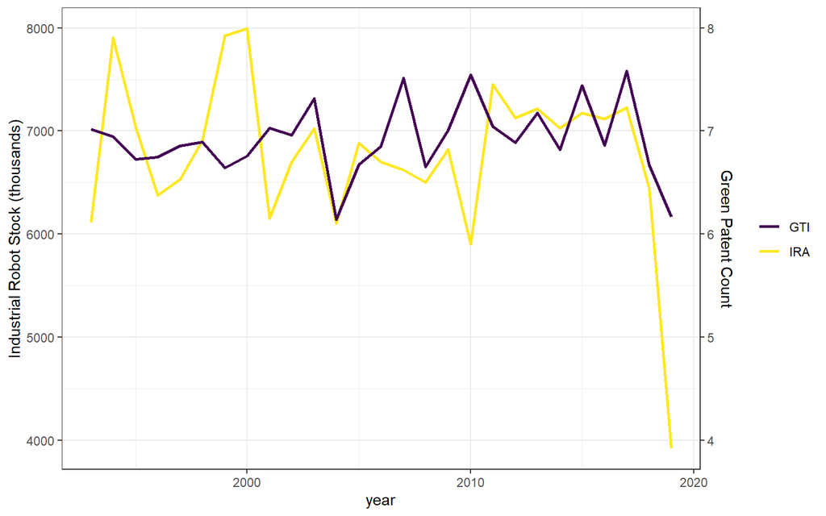

```r
# Aggregate yearly values
agg <- df %>% group_by(year) %>% summarise(
  IRA = sum(IRA, na.rm=TRUE),
  GTI = sum(GTI, na.rm=TRUE)
)

# Dual-axis plot
ggplot(agg, aes(x=year)) +
  geom_line(aes(y = IRA/100, color = "IRA"), size = 1) +
  geom_line(aes(y = GTI*50, color = "GTI"), size = 1) +
  scale_y_continuous(
    name = "Industrial Robot Stock (thousands)",
    sec.axis = sec_axis(~./1000, name = "Green Patent Count")
  ) +
  scale_color_manual(values = viridis(2), name = NULL) +
  theme_bw()
```